# Upgrading microbiome research in R/Bioc

18 12 2020

## Class structures for microbiome data

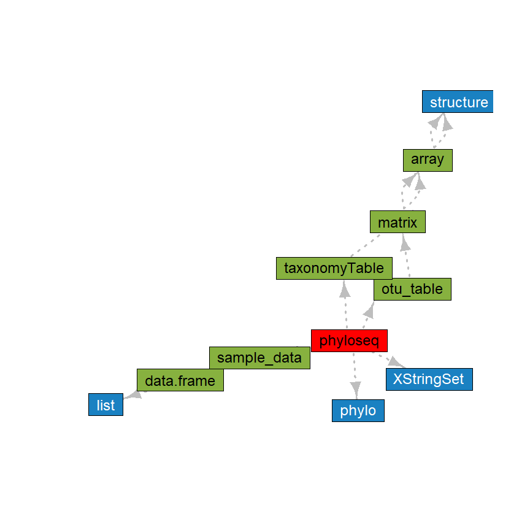

### `phyloseq`

The class mainly used for microbiome analysis

- slots for
  - count data
  - taxonomic data
  - sequence data
  - tree data
- 8+ years in Bioconductor
- similarities to `SummarizedExperiment`

(McMurdie et al. 2020)

## Class structures for microbiome data

### `TreeSummarizedExperiment`

[figure not shown]

- adds tree data to `SingleCellExperiment`
- all the benefits of the `SingleCellExperiment` related packages

(Huang 2020)

## Class structures for microbiome data

one additional data type required to match `phyloseq`: sequencing data

### Two options

1. Create `MicrobiomeExperiment` providing the `refSeq` slot while inheriting from `TreeSummarizedExperiment`
2. Add `refSeq` slot to `TreeSummarizedExperiment`

Currently this is implemented as 1., but the PR for adding it to `TreeSummarizedExperiment` is also in preparation.

## Functions for microbiome workflows

Specific functions for working with microbiome data need to be **added**/**implemented**/**wrapped** to work with `TreeSummarizedExperiment`.

The `mia` package is the playground for this and PRs are very welcome.

### Taxonomic data

- key component of microbiome data
- Instead of implementing a special class, on-the-fly subsetting of `rowData`

```r
library(mia)
data("GlobalPatterns")
se <- GlobalPatterns
taxonomyRanks(se)
```

```
## [1] "Kingdom" "Phylum"  "Class"   "Order"   "Family"  "Genus"   "Species"
```

## Functions for microbiome workflows

Specific functions for working with microbiome data need to be **added**/**implemented**/**wrapped** to work with `TreeSummarizedExperiment`.

The `mia` package is the playground for this and PRs are very welcome.

### Taxonomic data

- key component of microbiome data
- Instead of implementing a special class, on-the-fly subsetting of `rowData`

```r
head(taxonomyRankEmpty(se, "Species"))
```

```
## [1]  TRUE  TRUE FALSE  TRUE  TRUE  TRUE
```

```r
head(getTaxonomyLabels(se))
```

```
## [1] "Class:Thermoprotei"               "Class:Thermoprotei_1"
## [3] "Species:Sulfolobusacidocaldarius" "Class:Sd-NA"
## [5] "Class:Sd-NA_1"                    "Class:Sd-NA_2"
```

## Functions for microbiome workflows

### Converting taxonomic tabular data to tree data

`TreeSummarizedExperiment` already contains functions for generating data from hierarchical tabular data. `mia` adds wrapper functions.

```r
taxonomyTree(se)
```

```
##
## Phylogenetic tree with 1645 tips and 1089 internal nodes.
##
## Tip labels:
##   Species:Cenarchaeumsymbiosum, Species:pIVWA5, Species:CandidatusNitrososphaeragargensis, Species:SCA1145, Species:SCA1170, Species:Sulfolobusacidocaldarius, ...
## Node labels:
##   root:ALL, Kingdom:Archaea, Phylum:Crenarchaeota, Class:C2, Class:Sd-NA, Class:Thaumarchaeota, ...
##
## Rooted; includes branch lengths.
```

```r
se <- addTaxonomyTree(se)
```

## Functions for microbiome workflows

### Using the taxonomic levels

Data can be aggregated on a selected taxonomic rank.

```r
x <- agglomerateByRank(se, "Phylum")
dim(se)
```

```
## [1] 19216    26
```

```r
dim(x)
```

```
## [1] 67 26
```

Internally, constructs a factor to pass to `mia::mergeRows`, which uses `scater`/`scuttle` functions.

## Functions for microbiome workflows

### Using the taxonomic levels

`mia::splitByRanks` is a convenience wrapper around `agglomerateByRank`.

Results can be added to the alternative experiment slots inherited from `SCE`.

```r
altExps(se) <- splitByRanks(se, ranks = taxonomyRanks(se))
altExpNames(se)
```

```
## [1] "Kingdom" "Phylum"  "Class"   "Order"   "Family"  "Genus"   "Species"
```

Analysis can be performed individually on each taxonomic level.

```r
altExps(se) <-
   lapply(altExps(se),
          function(y){
              rowData(y)$prevalence <-
                  getPrevalence(y, detection = 1/100, sort = FALSE,
                                abund_values = "counts", as_relative = TRUE)
              y
          })
```

## Functions for microbiome workflows

### Using the taxonomic levels

Results from different taxonomic levels can be squashed into a `TreeSummarizedExperiment` using `mia::unsplitByRanks`.

```r
x <- addTaxonomyTree(unsplitByRanks(se))
x
```

```
## class: TreeSummarizedExperiment
## dim: 2692 26
## metadata(0):
## assays(1): counts
## rownames(2692): Kingdom:Archaea Kingdom:Bacteria ...
##   Species:Thermanaerovibrioacidaminovorans Species:Jonquetellaanthropi
## rowData names(9): Kingdom Phylum ... prevalence taxonomicLevel
## colnames(26): CL3 CC1 ... Even2 Even3
## colData names(7): X.SampleID Primer ... SampleType Description
## reducedDimNames(0):
## altExpNames(0):
## rowLinks: a LinkDataFrame (2692 rows)
## rowTree: a phylo (1645 leaves)
## colLinks: NULL
## colTree: NULL
```

## Functions for microbiome workflows

### Plotting data on a taxonomic tree

Plotting functions split of to `miaViz` package

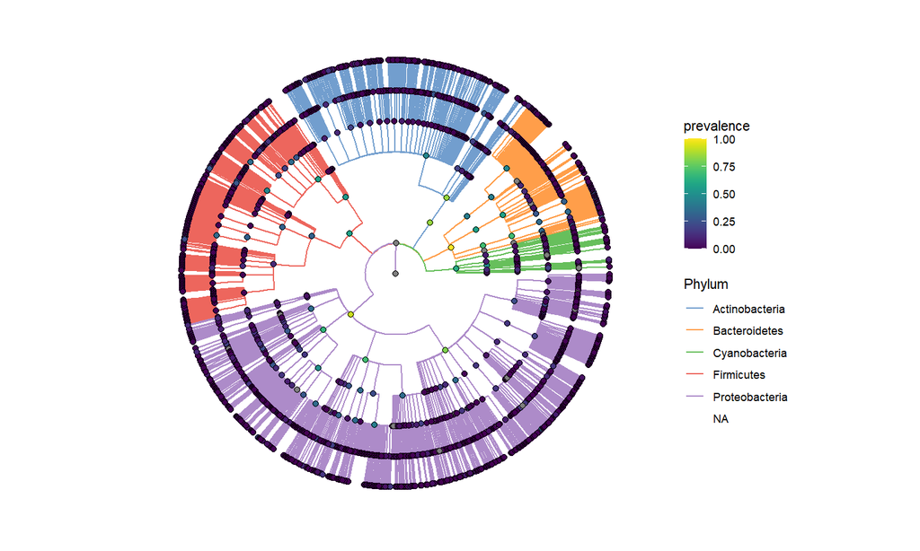

```r
library(miaViz)
top_phyla <- getTopTaxa(altExp(se,"Phylum"))
plotRowTree(x[rowData(x)$Phylum %in% top_phyla,], edge_colour_by = "Phylum",
            tip_colour_by = "prevalence", node_colour_by = "prevalence")
```

## Summary

**Contributors:** Tuomas Borman, Domenick J. Braccia, Hector Corrada Bravo, Ruizhu Huang, Leo Lahti, Sudarshan A.Shetty

### Additonal functions already available:

- convert/import functions for `biom`, `phyloseq` and `dada2`
- wrapper for alpha diversity estimates via `vegan` (`breakaway`/`DivNet` not available on `Bioc`, yet?)
- additional reduced dimension methods (JSD, UniFrac)
- in `Bioc-devel` the functions `calculateMDS`/`runMDS` from `scater` accept any distance measurement for so that all `vegdist` methods can be used for MDS.

**Questions? Thoughts? Suggestions?**

## Bibliography

Huang, Ruizhu. 2020. *TreeSummarizedExperiment: A S4 Class for Data with Tree Structures*.

McMurdie, Paul J., Susan Holmes, with contributions from Gregory Jordan, and Scott Chamberlain. 2020. *Phyloseq: Handling and Analysis of High-Throughput Microbiome Census Data*. http://dx.plos.org/10.1371/journal.pone.0061217.